# Exploratory Analysis

## Chart 1

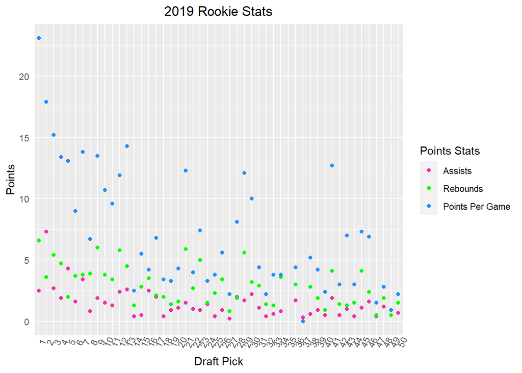

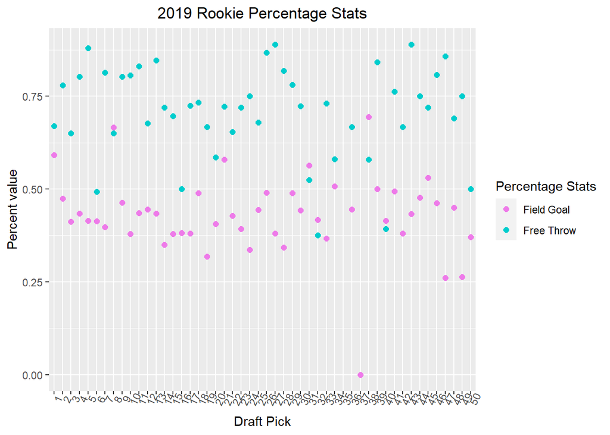

The first scatter plot shows the points, assists, and rebounds per game of the 2019 class in correlation with their draft pick position. Based on the observed data, it can be seen that higher draft picks performed better than lower ones, with higher rebounds and points per game, but not assists. Points per game varied the most, with assists varying the least. We can see that draft pick does matter for how well a player will play (with a few anomalies).

The second scatter plot shows the field goal and free throw percentage of the 2019 class in correlation with their draft pick position. Compared to the last graph, we can see that there is less variation, and a higher draft pick position isn’t conducive to higher percentages. When comparing both field goal and free throw percentages, field goal percentages among all 50 players are more similar in value than the free throw ones.